# Statistical Analysis of Lifestyle and Behavior Data

## S1.3

### Framkvæmið tilgátupróf til að svara rannsóknarspurningunni og túlkið niðurstöðurnar.

## V1.3

```r
# Hér er ég að tjékka á hvort það sé marktækur munur á því hvort fólk með mismunandi síma eða stýrikerfi sé meira fyrir hunda eða ketti?
prop.test(table(dat$styrikerfi_simi,dat$dyr))
```

```
##
##  2-sample test for equality of proportions with continuity correction
##
## data:  table(dat$styrikerfi_simi, dat$dyr)
## X-squared = 3.0916, df = 1, p-value = 0.0787
## alternative hypothesis: two.sided
## 95 percent confidence interval:
##  -0.24774067  0.01518038
## sample estimates:
##    prop 1    prop 2
## 0.5443038 0.6605839
```

## S1.4

### Nefnið hvaða bjagar gætu mögulega skekkt niðurstöðurnar eða rýrt alhæfingargildi þeirra.

## V1.4

### Eins og fram kom í „Undirbúningur fyrir yfirferð“ er hér aðeins um úrtak að ræða. Meirihluti þátttakenda er á aldrinum 18–25 ára og færri eru eldri. Allir þátttakendur eru í háskólanámi á Íslandi, og mögulega eru einhverjir þeirra ekki íslenskir ríkisborgarar, til dæmis skiptinemar, þannig það gæti mögulega haft áhrif á skekkju í niðurstöðum. Einn nemandi var fjarlægður úr gagnasafninu þar sem hann svaraði ekki spurningunni um hvaða stýrikerfi hann notar (NA), og því byggja niðurstöðurnar á 353 þátttakendum. Það ætti þó ekki að hafa veruleg áhrif á skekkjuna þar sem úrtakið er hóflega stórt. Það gæti samt verið bjagi í gagnasafninu, til dæmis úrtaksbjagi, ef úrtakið er ekki nægilega fjölbreytt eða flokkabjagi sem er að hóparnir eru kannski misstórir. Svo gæti það líka verið breytubjagi sem þýðir að aðrar breytur gæti haft áhrif á „dyr“ og „styrikerfi_simi“ breyturnar, til dæmis aldur.

## Loka niðurstaða

### Samkvæmt sem var unnið með, þá er engin marktækur munur á dýravali eftir því hvaða stýrikerfi fólk notar í símanum sínum. Því er rétt að samþykkja núlltilgátuna.

# Liður 2 - Ein Talnabreyta og ein flokkabreyta

## Um breyturnar

### Ein flokkabreyta var valin: „hljodfaeri“ sem segir okkur hvort að manneskjan spilar á hljóðfæri eða ekki.

### Í breytunni „hljodfaeri“ var spurt „Spilar þú á eitthvað hljóðfæri?“. Þátttakendur áttu að velja annað hvort „já“ eða „nei“.

### Ein talnabreyta var valin „likamsraekt_dagar“ sem segir okkur hversu oft persónan stundar líkamsrækt á viku.

### Í breytunni „likamsraekt_dagar“ var spurt „Hversu marga daga vikunnar stundar þú líkamsrækt að jafnaði?“. Þau áttu að setja inn tölu hversu oft þau gera það.

### Í næsta hluta mun ég vinna úr þessum gögnum og uppfylla þau atriði sem kennarinn setti fram.

## S2.1

### Setjið fram rannsóknarspurningu sem væri hægt að svara með því að bera saman meðaltöl talnabreytunnar milli ólíkra flokka flokkabreytunnar.

## V2.1

### H0: Það er ekki til marktækur munur á meðal fjölda líkamsræktardaga á viku milli einstaklinga sem spila á hljóðfæri og þeirra sem ekki spila?

### Ha: Það er til marktækur munur á meðal fjölda líkamsræktardaga á viku milli einstaklinga sem spila á hljóðfæri og þeirra sem ekki spila?

## S2.2

### Teiknið graf sem lýsir sambandi flokkabreytanna tveggja og lýsið því í samhengi við rannsóknarspurninguna.

## V2.2

### Í þessum hluta fer ég lengra en það sem var beðið um og það lítur út fyrir að ég sé ekki að svara spurningunni rétt, en fylgið mér.

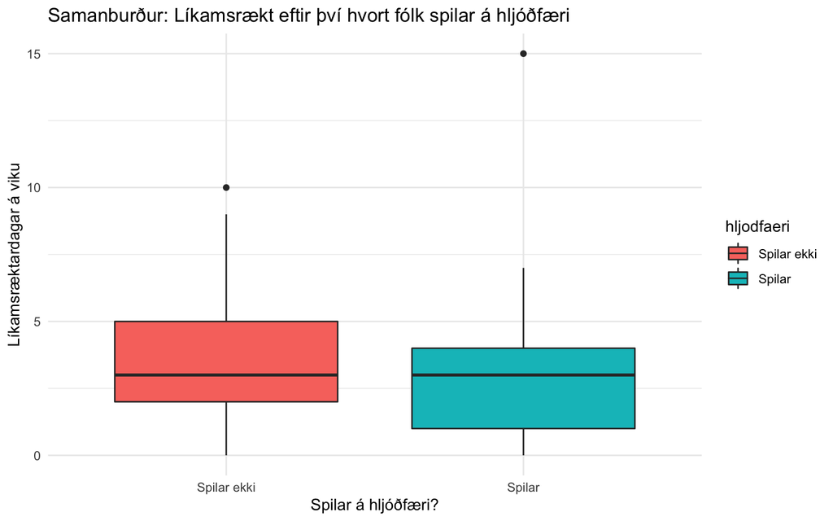

```r
dat_clean <- subset(dat, likamsraekt_dagar >= 0 & likamsraekt_dagar <= 15)
# Lína heér fyrir ofan er ég að setja limit á likamsrækta daga því að einn einstaklingur skrifaði -999999, sem er alls ekki viðeigandi punktur

dat_clean$hljodfaeri <- as.factor(dat_clean$hljodfaeri)
# Setja það í flokkbreytu

levels(dat_clean$hljodfaeri) <- c("Spilar ekki", "Spilar")
# Breyta Rétt og Rangt yfir í Spilar ekki og Spilar

ggplot(dat_clean, aes(x = hljodfaeri, y = likamsraekt_dagar, fill = hljodfaeri)) +
  geom_boxplot() +
  labs(
    x = "Spilar á hljóðfæri?",
    y = "Líkamsræktardagar á viku",
    title = "Samanburður: Líkamsrækt eftir því hvort fólk spilar á hljóðfæri"
  ) +
  theme_minimal()
```

```r
# Hér er ég að plotta grafið
```

### Þegar litið er á grafið sjáum við sirka hvor hópurinn hreyfir sig meira með tilliti til þess hvort hann spilar á hljóðfæri eða ekki. Við getum líka séð að það eru útlagar í gagnasafninu okkar, og slík öfgagildi geta haft áhrif á bæði meðaltal og staðalfrávik og þannig skekkt niðurstöðurnar. Því ætla ég að fjarlægja útlagagildin úr gagnasafninu. En fyrst þarf ég að reikna hvaða punktar teljast vera útlagar.

```r
outliers <- dat_clean %>%
  group_by(hljodfaeri) %>%
  mutate(
    Q1 = quantile(likamsraekt_dagar, 0.25, na.rm = TRUE),
    Q3 = quantile(likamsraekt_dagar, 0.75, na.rm = TRUE),
    IQR = Q3 - Q1,
    lower_bound = Q1 - 1.5 * IQR,
    upper_bound = Q3 + 1.5 * IQR,
    is_outlier = likamsraekt_dagar < lower_bound | likamsraekt_dagar > upper_bound
  ) %>%
  filter(is_outlier) %>%
  select(hljodfaeri, likamsraekt_dagar)

print(outliers)
```

```
## # A tibble: 2 × 2
## # Groups:   hljodfaeri [2]
##   hljodfaeri  likamsraekt_dagar
##   <fct>                   <dbl>
## 1 Spilar ekki                10
## 2 Spilar                     15
```

```r
# Þessi kóði hér fyrir ofan er ég að finna frávik í fjölda líkamsræktardaga innan hvers hljodfaeri hóps með því að nota IQR-aðferðina. Svo í lokin prenta ég út gagna punktana sem eru útlagar.
```

### Glugginn hér fyrir ofan sýnir mér hvaða punktar teljast útlagar. Gildin 10 og 15 eru útlagar, og nú ætla ég að fjarlægja þau úr gagnasafninu. Ég geri það með því að takmarka gildin í breytunni likamsraekt_dagar niður í 9.

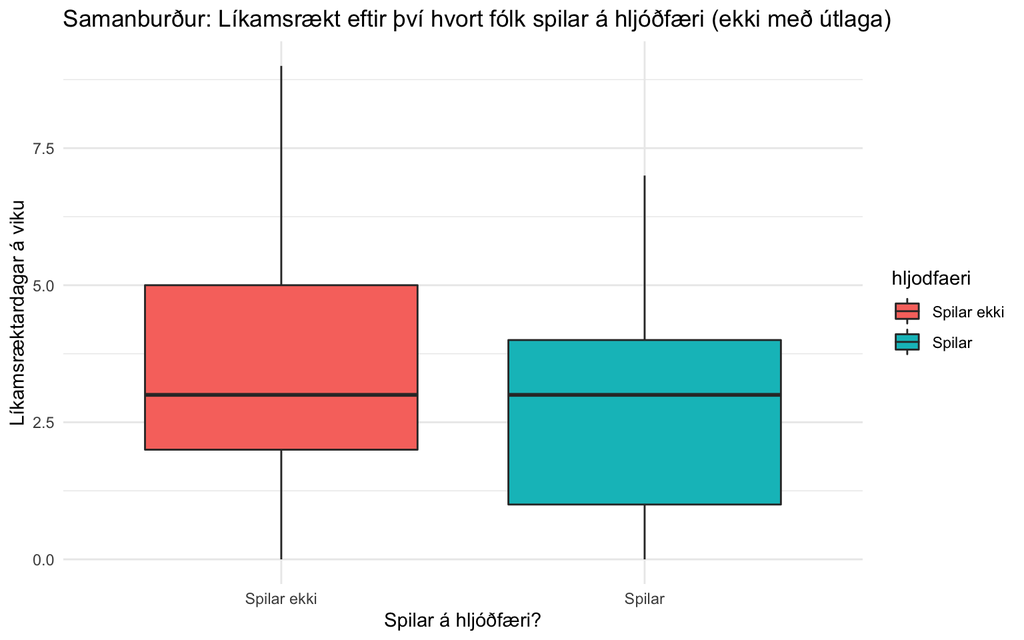

```r
dat_clean <- subset(dat, likamsraekt_dagar >= 0 & likamsraekt_dagar <= 9)
# Línan hér fyrir ofan er ég að setja nýtt limit á líkamsrækta-daga útaf útlagapunktunum sem var 10 og 15
dat_clean$hljodfaeri <- as.factor(dat_clean$hljodfaeri)
# Sama og síðast, bara að setja í flokkabreytu
levels(dat_clean$hljodfaeri) <- c("Spilar ekki", "Spilar")
# Breyta Rétt og Rangt yfir í Spilar ekki og Spilar
ggplot(dat_clean, aes(x = hljodfaeri, y = likamsraekt_dagar, fill = hljodfaeri)) +
  geom_boxplot() +
  labs(
    x = "Spilar á hljóðfæri?",
    y = "Líkamsræktardagar á viku",
    title = "Samanburður: Líkamsrækt eftir því hvort fólk spilar á hljóðfæri (ekki með útlaga)"
  ) +
  theme_minimal()
```

```r
# Hér fyrir ofan þá er ég að bara að plotta grafið
```

### Ekki hafa átt sér stað mjög stórar breytingar eftir að hafa þurrkað útlagana úr safninu, en þær eru nægjanlegar til að hafa áhrif á meðaltöl og draga úr mun á staðalfrávikum. Nú er góður tími til þess að svara atriðinu sem þið eruð örugglega búin að bíða spennt eftir og það er að lýsa samhengi við rannsóknarspurninguna þegar ég er búinn að teikna grafið.

### Grafið sýnir dreifingu þess hversu mikið fólk stundar líkamsrækt vikulega með tillit til ef þau spila hljóðfæri eða ekki. Sjáum úr uppfærða grafinu (ekki með útlaga) að hópurinn sem spila ekki hljóðfæri stundar að meðaltali meira líkamsrækt heldur en hópinn sem spilar á hljóðfæri. Þótt það virðist við fyrstu sýn sem hópurinn sem spilar ekki hljóðfæri séu líklegri til að stunda líkamsrækt, er mikilvægt að framkvæma viðeigandi tölfræðipróf til að staðfesta hvort munurinn sé tölfræðilega marktækur. Slíkt próf verður framkvæmt í V2.4

## S2.3

### Takið fram hver meðaltal talnabreytunnar er innan hvers hóps.

## V2.3

```r
summary_stats <- dat_clean %>%
  group_by(hljodfaeri) %>%
  summarise(
    count = n(),
    mean = round(mean(likamsraekt_dagar, na.rm = TRUE), 2),
    median = median(likamsraekt_dagar, na.rm = TRUE),
    sd = round(sd(likamsraekt_dagar, na.rm = TRUE), 2),
    min = min(likamsraekt_dagar, na.rm = TRUE),
    max = max(likamsraekt_dagar, na.rm = TRUE)
  )
print(summary_stats)
```

```
## # A tibble: 2 × 7
##   hljodfaeri  count  mean median    sd   min   max
##   <fct>       <int> <dbl>  <dbl> <dbl> <dbl> <dbl>
## 1 Spilar ekki   211  3.29      3  2.1      0     9
## 2 Spilar        140  2.75      3  2.03     0     7
```

```r
# Þessi kóði hér fyrir ofan er ég að prenta út mikilvæg gildi eins og maðaltal, miðgildi, staðalfrávik, lágmark og hámark.
```

### Í glugganum hér fyrir ofan er samanlögð helstu tölfræði niðurstöður. En það virðist hafa verið spurt um meðaltöl innan hvers hóps. Ég gef þær hér fyrir neðan, skýrt og greinilega.

### Hópurinn sem spilar ekki á hljóðfæri fer á meðaltali í líkamsrækt 3,29 sinnum á viku.

### Hópurinn sem spilar á hljóðfæri fer á meðaltali í líkamsrækt 2.75 sinnum á viku.

## S2.4

### Framkvæmið hefðbundið tilgátupróf til að svara rannsóknarspurningunni og túlkið niðurstöðurnar.

## V2.4

```r
# T-próf: óháð úrtök, assume unequal variance just in case
t_test_result <- t.test(likamsraekt_dagar ~ hljodfaeri, data = dat_clean, var.equal = FALSE)

print(t_test_result)
```

```
##
##  Welch Two Sample t-test
##
## data:  likamsraekt_dagar by hljodfaeri
## t = 2.4104, df = 305.41, p-value = 0.01653
## alternative hypothesis: true difference in means between group Spilar ekki and group Spilar is not equal to 0
## 95 percent confidence interval:
##  0.0992207 0.9813819
## sample estimates:
## mean in group Spilar ekki      mean in group Spilar
##                  3.286730                  2.746429
```

```r
# Hæer fyrir ofan er ég að gera viðeigandi próf (Welch two sample t-test)
```

```r
anova_result <- aov(likamsraekt_dagar ~ hljodfaeri, data = dat_clean)

summary(anova_result)
```

```
##              Df Sum Sq Mean Sq F value Pr(>F)
## hljodfaeri    1   24.6  24.568   5.723 0.0173 *
## Residuals   349 1498.2   4.293
## ---
## Signif. codes:  0 '***' 0.001 '**' 0.01 '*' 0.05 '.' 0.1 ' ' 1
```

```r
# Kóðinn hér fyrir ofan er framkvæma ANOVA próf til að athuga hvort marktækur munur sé á meðaltali likamsraekt_dagar milli margra hljodfaeri hópa.
```

### Samkvæmt T-prófi sem framkvæmt var í glugganum hér fyrir ofan, kom í ljós tölfræðilega marktækur munur á meðalfjölda líkamsræktardaga á viku milli þeirra sem spila á hljóðfæri og þeirra sem ekki gera það. Í stuttu máli var P-gildið lægra en 0,05. Því er hægt að hafna núlltilgátunni og samþykkja gagntilgátuna.

## S2.5

### Kannið hvort forsendur tilgátuprófsins halda.

## V2.5

```r
bartlett.test(likamsraekt_dagar ~ hljodfaeri, data = dat_clean)
```

```
##
##  Bartlett test of homogeneity of variances
##
## data:  likamsraekt_dagar by hljodfaeri
## Bartlett's K-squared = 0.22848, df = 1, p-value = 0.6327
```

### Bartlett-prófið skoðar hvort dreifni likamsraekt_dagar sé sú sama milli hljodfaeri hópa. Með p-gildi upp á 0.63 er engin marktæk vísbending um ólíka dreifni, sem þýðir að líkamsræktardreifingin er svipuð á milli hópanna. Þú má gera ráð fyrir jöfnum dreifni.

## S2.6

### Framkvæmið einnig umraðanapróf til að svara rannsóknarspurningunni. Berið saman niðurstöður þess og hefðbundna tilgátuprófsins og útskýrið hvers vegna niðurstöðurnar eru svipaðar eða ólíkar - eftir því sem við á.

## V2.6

```r
# dat_clean <- dat[dat$likamsraekt_dagar != -999999, ] # Það var einn einstaklingur sem svaraði -999999
tapply(dat_clean$likamsraekt_dagar, dat_clean$hljodfaeri, mean)
```

```
## Spilar ekki      Spilar
##    3.286730    2.746429
```

```r
diff(tapply(dat_clean$likamsraekt_dagar, dat_clean$hljodfaeri, mean))
```

```
##     Spilar
## -0.5403013
```

```r
tmp <- replicate(100000, diff(tapply(dat_clean$likamsraekt_dagar, sample(dat_clean$hljodfaeri), mean)))
quantile(tmp, c(0.025, 0.975))
```

```
##       2.5%      97.5%
## -0.4452437  0.4399797
```

```r
# Hér er ég að gera umraðanarpróf
```

### Bæði umraðanaprófið og hefðbundna t-prófið benda til þess að marktækur munur sé á meðal fjölda líkamsræktardaga milli þeirra sem spila á hljóðfæri og þeirra sem ekki gera það. Meðaltalsmunurinn mældist -0.54 dagar og var utan öryggisbilsins frá umraðanaprófinu [−0.445,0.440] [−0.445,0.440], sem styður höfnun núlltilgátunnar í báðum tilfellum. Þar sem úrtakið er stórt, skýrir Central Limit Theorem hvers vegna niðurstöðurnar úr báðum prófunum eru svipaðar. Þetta bendir til þess að þeir sem ekki spila á hljóðfæri stundi líkamsrækt örlítið oftar.

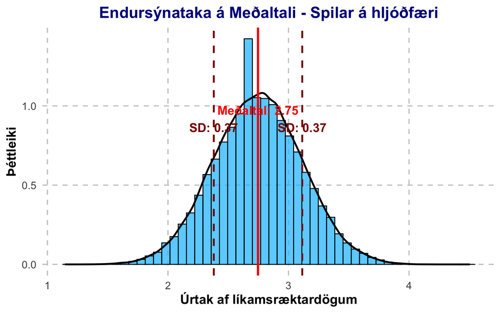

```r
set.seed(080799)

players <- subset(dat_clean, hljodfaeri == "Spilar")
clean_players <- na.omit(players$likamsraekt_dagar)
medaltol_players <- replicate(100000, mean(sample(clean_players, 30, replace = TRUE)))
mean_p <- mean(medaltol_players)
sd_p <- sd(medaltol_players)

ggplot(data = data.frame(medaltol_players), aes(x = medaltol_players)) +
geom_histogram(aes(y = ..density..), bins = 50, fill = "deepskyblue", color = "black", alpha = 0.7) +
geom_density(color = "black", size = 1) +
geom_vline(aes(xintercept = mean_p), color = "red", size = 1.2) +
geom_vline(aes(xintercept = mean_p - sd_p), color = "darkred", linetype = "dashed", size = 1) +
geom_vline(aes(xintercept = mean_p + sd_p), color = "darkred", linetype = "dashed", size = 1) +
annotate("text", x = mean_p, y = max(density(medaltol_players)$y) * 0.9,
label = paste("Meðaltal:", round(mean_p, 2)), color = "red", size = 5, fontface = "bold") +
annotate("text", x = mean_p - sd_p, y = max(density(medaltol_players)$y) * 0.8,
label = paste("SD:", round(sd_p, 2)), color = "darkred", size = 5, fontface = "bold") +
annotate("text", x = mean_p + sd_p, y = max(density(medaltol_players)$y) * 0.8,
label = paste("SD:", round(sd_p, 2)), color = "darkred", size = 5, fontface = "bold") +
labs(
title = "Endursýnataka á Meðaltali - Spilar á hljóðfæri",
x = "Úrtak af líkamsræktardögum",
y = "Þéttleiki"
) +
theme_minimal(base_size = 15) +
theme(
plot.title = element_text(hjust = 0.5, face = "bold", color = "darkblue"),
axis.title = element_text(face = "bold"),
panel.grid.minor = element_blank(),
panel.grid.major = element_line(color = "gray80", linetype = "dashed")
)
```

```r
# Hér fyrir ofan er ég að framkvæma umraðanarpróf með 100000 úrtök af stærð 30 og svo plotta grafið upp. En er bara að plotta hópinn sem spilar á hljóðfæri
```

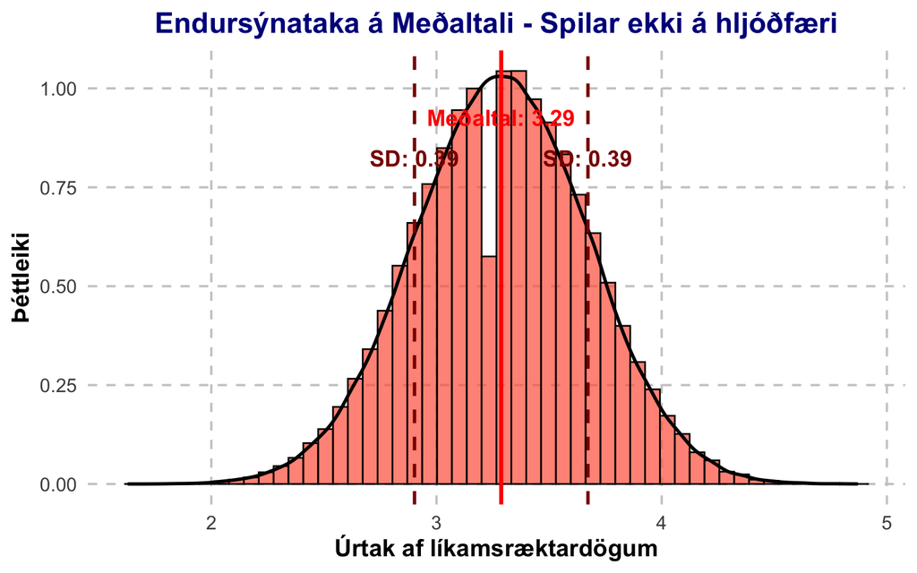

```r
set.seed(080799)
non_players <- subset(dat_clean, hljodfaeri == "Spilar ekki")
clean_nonplayers <- na.omit(non_players$likamsraekt_dagar)
medaltol_non <- replicate(100000, mean(sample(clean_nonplayers, 30, replace = TRUE)))
mean_np <- mean(medaltol_non)
sd_np <- sd(medaltol_non)

ggplot(data = data.frame(medaltol_non), aes(x = medaltol_non)) +
geom_histogram(aes(y = ..density..), bins = 50, fill = "tomato", color = "black", alpha = 0.7) +
geom_density(color = "black", size = 1) +
geom_vline(aes(xintercept = mean_np), color = "red", size = 1.2) +
geom_vline(aes(xintercept = mean_np - sd_np), color = "darkred", linetype = "dashed", size = 1) +
geom_vline(aes(xintercept = mean_np + sd_np), color = "darkred", linetype = "dashed", size = 1) +
annotate("text", x = mean_np, y = max(density(medaltol_non)$y) * 0.9,
label = paste("Meðaltal:", round(mean_np, 2)), color = "red", size = 5, fontface = "bold") +
annotate("text", x = mean_np - sd_np, y = max(density(medaltol_non)$y) * 0.8,
label = paste("SD:", round(sd_np, 2)), color = "darkred", size = 5, fontface = "bold") +
annotate("text", x = mean_np + sd_np, y = max(density(medaltol_non)$y) * 0.8,
label = paste("SD:", round(sd_np, 2)), color = "darkred", size = 5, fontface = "bold") +
labs(
title = "Endursýnataka á Meðaltali - Spilar ekki á hljóðfæri",
x = "Úrtak af líkamsræktardögum",
y = "Þéttleiki"
) +
theme_minimal(base_size = 15) +
theme(
plot.title = element_text(hjust = 0.5, face = "bold", color = "darkblue"),
axis.title = element_text(face = "bold"),
panel.grid.minor = element_blank(),
panel.grid.major = element_line(color = "gray80", linetype = "dashed")
)
```

```r
# Hér fyrir ofan er ég að framkvæma umraðanarpróf með 100000 úrtök af stærð 30 og svo plotta grafið upp. En er bara að plotta hópinn sem spilar ekki á hljóðfæri
```

### Þessi mynd hér að ofan sýnir 100.000 endursýnatökur með úrtökum af stærð 30 úr hópi sem spilar ekki á hljóðfæri. Það má segja hið sama við þennan hóp eins og um hópinn sem spilar á hljóðfæri, allt virðist vera í lagi, nema þessi eina súla sem sker sig verulega úr og fylgir því ekki eðlilegri hegðun normaldreifingar.

## S2.7

### Nefnið hvaða bjagar gætu mögulega skekkt niðurstöðurnar eða rýrt alhæfingargildi þeirra.

## V2.7

### Útlagar geta skekkt meðaltal og dreifni, en aðrir bjagar eins og lélegt úrtak, mælivillur, samverkandi breytur (aldur, lífsstíll o.fl.) og tímabundin áhrif geta líka rýrt alhæfingargildi niðurstaðna.

## Loka niðurstaða

### Samkvæmt sem var unnið með þá sýna gögnin að einstaklingar sem spila ekki á hljóðfæri stunda líkamsrækt um hálfan dag meira á viku en þau sem spila á hljóðfæri (3,29 við 2,75 dagar), og með marktæku p-gildi upp á 0,0165. Rétt væri að samþykkja gagntilgátuna.

# Liður 3 - Tvær talnabreytur

## Um breyturnar

### Tvær talnabreytur voru valdar: „likamsraekt_dagar“ og „aramotaskaupid“.

### Ein talnabreyta var valin „likamsraekt_dagar“ sem segir okkur hversu oft persónan stundar líkamsrækt á viku.

### Í breytunni „likamsraekt_dagar“ var spurt „Hversu marga daga vikunnar stundar þú líkamsrækt að jafnaði?“. Þau átti að setja inn tölu hversu oft þau gera það.

### Hin talnabreytan er „aramotaskaupid“ sem segir okkur hversu mikið persónan líkaði við áramótaskaupið.

### Í breytunni „aramotaskaupid“ var spurt „Á skalanum frá 0 upp í 10, hversu skemmtilegt fannst þér áramótaskaupið?“.

### Í næsta hluta mun ég vinna úr þessum gögnum og uppfylla þau atriði sem kennarinn setti fram.

## S3.1

### Setjið fram rannsóknarspurningu sem væri hægt að svara með því að bera saman talnabreyturnar tvær.

## V3.1

### H0: Það er enginn tölfræðilega marktækur munur á mati einstaklinga á áramótaskaupinu eftir því hvort þeir stunda líkamsrækt meira eða minna

### Ha: Það er tölfræðilega marktækur munur á mati einstaklinga á áramótaskaupinu eftir því hvort þeir stunda líkamsrækt meira eða minna

## S3.2

### Teiknið graf sem að lýsir sambandi þeirra og lýsið því í samhengi við rannsóknarspurninguna.

## V3.2

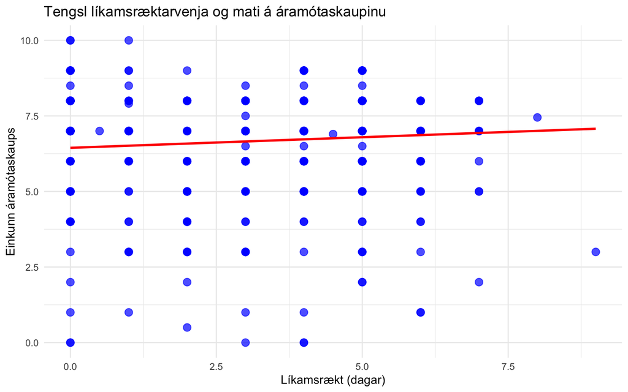

```r
ggplot(dat_clean, aes(x = likamsraekt_dagar, y = aramotaskaupid)) +
  geom_point(color = "blue", size = 3, alpha = 0.7) +
  geom_smooth(method = "lm", se = FALSE, color = "red") +
  labs(title = "Tengsl líkamsræktarvenja og mati á áramótaskaupinu",
       x = "Líkamsrækt (dagar)",
       y = "Einkunn áramótaskaups") +
  coord_cartesian(ylim = c(0, 10)) +
  theme_minimal()
```

```r
# Þessi R-kóði hér fyrir ofan býr til  punktarit sem sýnir tengslin milli likamsraekt_dagar (líkamsræktardaga) og aramotaskaupid (einkunn áramótaskaupsins). Bláir punktar tákna gögnin, rauða línan sýnir línulega þróun. Y-ásinn er limit-aður frá 0 til 10.
```

### Grafið sýnir dreifingu einkunna áramótaskaupsins eftir fjölda líkamsræktardaga. Bláu punktarnir eru einstaklingar, og rauða línan er línulegt aðhvarf sem sýnir þróunina. Línan hallar örlítið upp, en hún er svo lítil að hún gæti verið að það sé engin fylgni. Til þess að komast að því er mikilvægt að framkvæma prófanir, og það verður gert í hluta V3.4.

## S3.3

### Setjið fram lýsistærð sem lýsir sambandi þeirra.

## V3.3

```r
model <- lm(likamsraekt_dagar ~ aramotaskaupid, data = dat_clean)
summary(model)
```

```
##
## Call:
## lm(formula = likamsraekt_dagar ~ aramotaskaupid, data = dat_clean)
##
## Residuals:
##     Min      1Q  Median      3Q     Max
## -3.1283 -2.0492 -0.0756  1.8980  5.9639
##
## Coefficients:
##                Estimate Std. Error t value Pr(>|t|)
## (Intercept)     2.99654    0.19220  15.590   <2e-16 ***
## aramotaskaupid  0.01318    0.02342   0.563    0.574
## ---
## Signif. codes:  0 '***' 0.001 '**' 0.01 '*' 0.05 '.' 0.1 ' ' 1
##
## Residual standard error: 2.082 on 342 degrees of freedom
##   (7 observations deleted due to missingness)
## Multiple R-squared:  0.0009245,  Adjusted R-squared:  -0.001997
## F-statistic: 0.3165 on 1 and 342 DF,  p-value: 0.5741
```

```r
# Er að keyra línulega aðhvarfsgreiningu
```

### Í þessari línulegu aðhvarfsgreiningu var kannað hvort einkunn áramótaskaupsins (aramotaskaupid) hefði forspárgildi fyrir fjölda líkamsræktardaga á viku. Niðurstöðurnar sýna að tengslin eru ekki marktæk. Hallatala (β) fyrir áramótaskaupið er 0.013 með p-gildi 0.574, sem er langt frá því að teljast marktækt. Með öðrum orðum, það er engin tölfræðilega marktæk tengsl milli þess hversu mikið fólki líkar við áramótaskaupið og hversu oft það fer í ræktina. R² gildið er 0.0009, sem þýðir að máttur líkansins er nær engin. Ekki einu sinni örlítið hint af línulegri tengingu þarna.

## S3.4

### Framkvæmið hefðbundið tilgátupróf til að svara rannsóknarspurningunni ykkar og túlkið niðurstöðurnar.

## V3.4

```r
median_val <- median(dat_clean$likamsraekt_dagar, na.rm = TRUE)
dat_clean$exercise_group <- ifelse(dat_clean$likamsraekt_dagar > median_val, "more", "less")
t_result <- t.test(aramotaskaupid ~ exercise_group, data = dat_clean)
print(t_result)
```

```
##
##  Welch Two Sample t-test
##
## data:  aramotaskaupid by exercise_group
## t = -0.65754, df = 256.59, p-value = 0.5114
## alternative hypothesis: true difference in means between group less and group more is not equal to 0
## 95 percent confidence interval:
##  -1.4193217  0.7087489
## sample estimates:
## mean in group less mean in group more
##           6.499521           6.854808
```

```r
# Þessi R-kóði hér fyrir ofan framkvæmir t-próf til að athuga hvort einkunn áramótaskaupsins (aramotaskaupid) sé mismunandi eftir því hvort fólk fer meira eða minna en miðgildi í ræktina
```

### Í þessu tilgátuprófi var ætlað að kanna hvort það sé tölfræðilega marktækur munur á mati einstaklinga á áramótaskaupinu miðað við hversu oft persónan stundar líkamsrækt Það var notuðum Welch Two Sample t-próf þar sem hópurinn sem stunda minni líkamsrækt hafði meðaltal einkunnar um 6.50 og sá sem stunda meiri líkamsrækt nálægt 6.85. Prófunin leiddi til t-gildis –0.65754 með frjálsum stigum 256.59 og p-gildi 0.5114, sem er mun hærra en hefðbundið 0.05 viðmið. Öryggisbilið fyrir muninn var reiknað sem (-1.42, 0.71), sem inniheldur gildið 0. Þessar niðurstöður styðja núlltilgátuna um að enginn tölfræðilega marktækur munur sé til staðar, sem bendir til þess að munurinn í mati sé of lítill til að draga ályktanir um áhrif líkamsræktarvenja á áramótaskaupið.